# Univariate Plots Section

# In this grapg we can clearly see that in qualtiy 3 and 8 the slope of the model is more than the rest(negatively). While the rest was not that big correlation but quality 6 is really different as there is a slight positive relation between alcohol and citric (first plot using almost one color but in the second multiple colors )

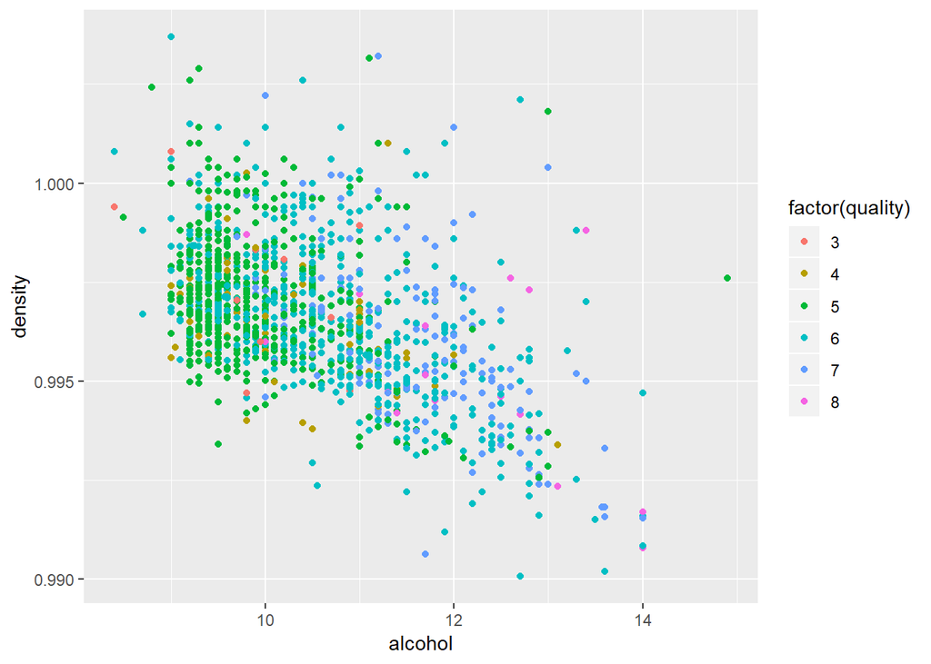

```r
ggplot(data = red_wine2,
       aes(x = alcohol, y = density, color = factor(quality)))+
  geom_point()
```

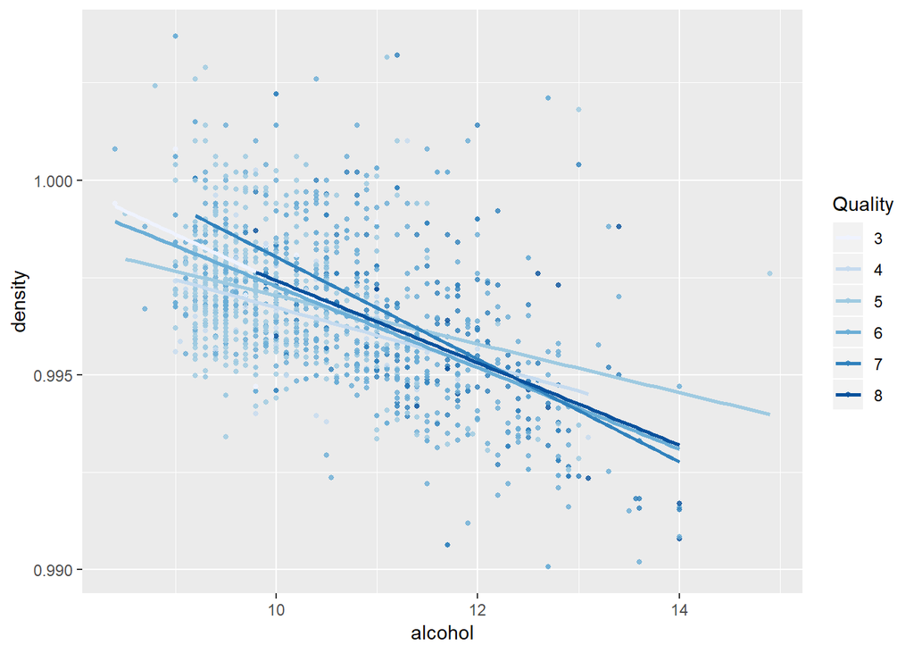

```r
ggplot(aes(x = alcohol,
           y = density  , color = factor(quality)),
       data = red_wine2) +
      geom_point(alpha = 0.8, size = 1) +
      geom_smooth(method = "lm", se = FALSE,size=1)  +
  scale_color_brewer(type='seq',
                   guide=guide_legend(title='Quality'))
```

We can see that all of them show a negtive relation between the alcohol variable and density . Moreover as we move to further to the right(increase in alcohol quantity) and and decrease the density the points of higher quality wine appears

# Multivariate Analysis

### Talk about some of the relationships you observed in this part of the investigation. Were there features that strengthened each other in terms of looking at your feature(s) of interest?

When I looked at the effect of of both the fixed acidity and ph on the quality of the data , I found what I was searching for , we cannot say the effect of them on the quality .

While for alcohol and citric acid we can see that quality 8 is either on high alcohol or high citric acid. Quality 5 is concentrated in the lower left area. While 6 is dispersed all over the graph .

In Quality we can see 5 concentrated in normal density and low alcohol and as we move to the right we can that quality is changing to be more 6 and also even while decreasing in the density. we also can view that quality 8 is in the lower right or upper right but as we go up and to the left we find that as increased in density and decrease in alcohol there will be lesser quality

### Were there any interesting or surprising interactions between features?

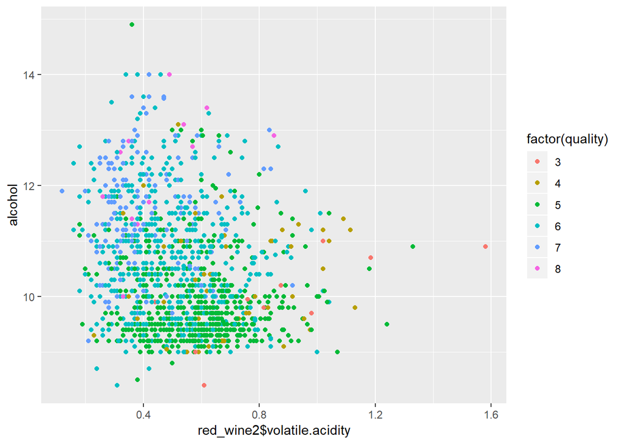

```r
ggplot(data = red_wine2,
       aes(x = red_wine2$volatile.acidity, y = alcohol, color = factor(quality)))+
  geom_point()
```

# Final Plots and Summary

### Plot One

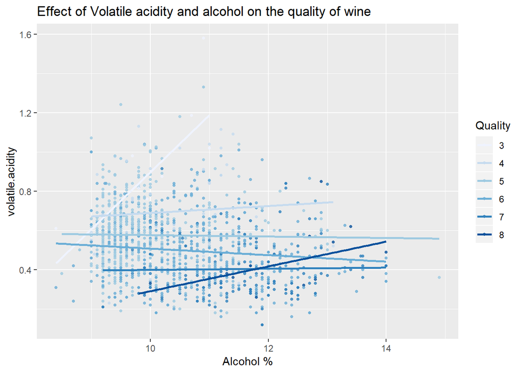

### Description One

Both alcohol and voaltile acidity have a positive relation between wach other in both quality 3 and 8 and not that big effect on the rest of the other qualities.

### Plot Two

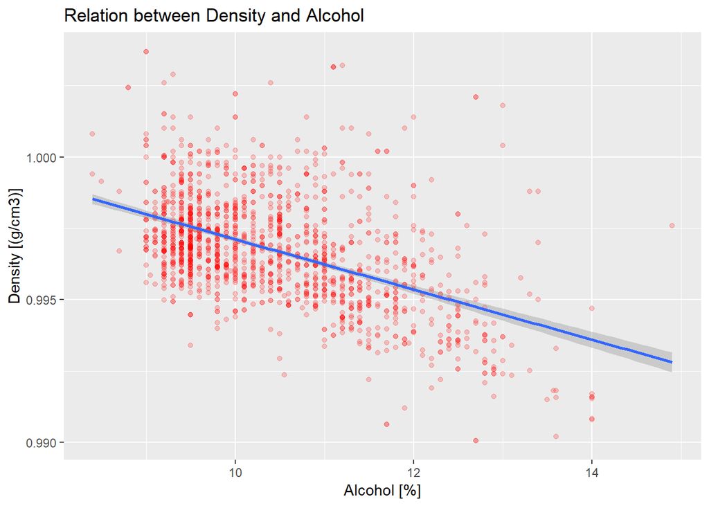

### Description Two

As we can see that the relation between both Variables in our data set is vice versa ,as we can see in this graph, the higher the alcohol the lower the density.

### Plot Three

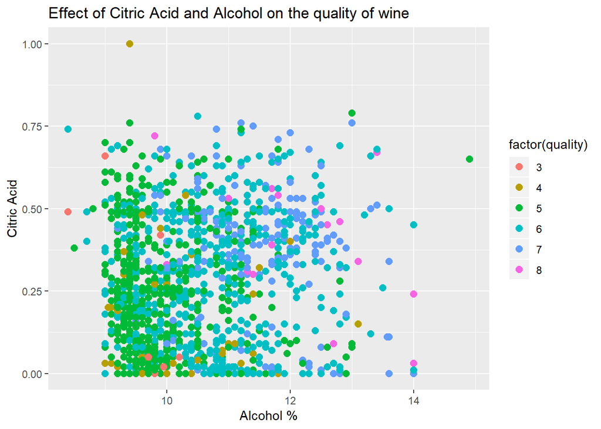

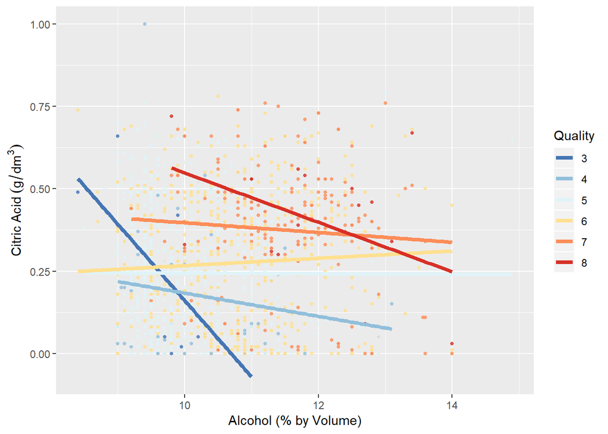

### Description Three

As we can see in the third plot which shows the effect of citric acid and alcohol on the quality of wine that most of the wine with qualtiy 5 is when the alcohol level level between 9 and 10 and there is not that big effect on the quality of wine even though with the increase or decrease of citric Acid while Citric Acid has a positive effect on the quality of wine if seen alone. The higher the Quality is associated with higher citric Acid.

while in the second plot we can see that citric acid and alcohol have a negative or vice versa relation between each other which can be noticed on both 8 and 3

# Reflection

Yh there were some struggles to know what is the the factors that is directly associated with the quality of wine , dealing with the RMD file in the beginning but now I am familiar more with this type of files.